# Project - Part 2

- Show All Code
- Hide All Code
- View Source

Scoring, M2 Data Science for Social Sciences

Author

Théo Druilhe, Pierre Larose, Nathan Pizzetta, Sigurd Saue

```r
library(tidyverse)
library(survival)
library(dplyr)
# install.packages("naniar")
library(naniar)
# install.packages("mice")
library(mice)
library(tidyr)
library(ggplot2)
library(reshape2)
#install.packages("survival")
library(broom)
library(stats)
library(pROC)
```

## Data Manipulation

### Data Importation

```r
setwd("/Users/theodruilhe/Documents/M2_D3S/scoring_project")

# Import X
file_path <- file.path("data", "our_data", "X.rds")
if (file.exists(file_path)) {
  X <- readRDS(file_path)
} else {
  print("File not found. Please check the file path.")
}

# import target_Y
file_path <- file.path("data", "our_data", "target_Y.rds")
if (file.exists(file_path)) {
  y <- readRDS(file_path)
} else {
  print("File not found. Please check the file path.")
}
```

Create an new ID for the join

```r
X <- X %>%
  mutate(ID = paste(gvkey, fyear, sep = "_"))
y <- y %>%
  mutate(ID = paste(gvkey, fyear, sep = "_"))
```

### Data Quality check

Function to calculate the number of duplicates

```r
count_duplicates <- function(data) {
  # Total number of rows in the dataset
  number_of_rows <- nrow(data)

  # Number of distinct IDs
  distinct_count <- data %>%
    ungroup() %>%
    summarise(total_distinct_IDs = n_distinct(ID)) %>%
    pull(total_distinct_IDs) # Extract the numeric value

  # Calculate and return the number of duplicates
  number_of_duplicates <- number_of_rows - distinct_count
  return(number_of_duplicates)
}
```

#### Duplicates in X

```r
duplicates_count_X <- count_duplicates(X)
print(duplicates_count_X)
```

```
[1] 46
```

```r
duplicates_X <- X %>%
  group_by(ID) %>%
  filter(n() > 1) %>%
  ungroup()

print(duplicates_X)
```

```
# A tibble: 92 × 20
   fyear gvkey       ROA      ROE net_profit_margin asset_turnover
   <int> <chr>     <dbl>    <dbl>             <dbl>          <dbl>
 1  2010 028543 -0.00430 -0.00907          -0.00244          1.76
 2  2010 002176  0.0348   0.0824            0.0960           0.363
 3  2010 020217  0.192   -4.46              0.549            0.350
 4  2010 002176  0.0348   0.0824            0.0960           0.363
 5  2010 028543 -0.00430 -0.00907          -0.00244          1.76
 6  2010 020217  0.192   -4.46              0.549            0.350
 7  2011 017266 -0.0180  -0.0437           -0.0188           0.956
 8  2011 032280  0.105    0.154             0.269            0.392
 9  2011 183812 NA       NA                NA               NA
10  2011 017266 -0.0180  -0.0437           -0.0188           0.956
# ℹ 82 more rows
# ℹ 14 more variables: inventory_turnover <dbl>, debt_to_equity <dbl>,
#   debt_ratio <dbl>, PE_ratio <dbl>, market_to_book <dbl>,
#   operating_cash_flow_to_debt <dbl>, free_cash_flow_to_sales <dbl>,
#   book_value <dbl>, ebitda <dbl>, ebitda_margin <dbl>, roic <dbl>,
#   leverage <dbl>, interest_coverage <dbl>, ID <chr>
```

For the duplicates rows the values of the columns are the same but not for not for the “PE_ratio” and “market_to_book” thus we will investigate the computation this columns.

We choose to keep only the smallest value for theses variables in case of duplicates

```r
X <- X %>%
  group_by(ID) %>% # Group by ID to handle duplicates
  arrange(PE_ratio, market_to_book) %>% # Sort by smallest PE_ratio and market_to_book
  slice(1) %>% # Keep only the first row (smallest values)
  ungroup() # Remove grouping
```

We check for other duplicates

```r
duplicates_count_X <- count_duplicates(X)
print(duplicates_count_X)
```

```
[1] 0
```

#### Duplicates in Y

```r
duplicates_count_y <- count_duplicates(y)
print(duplicates_count_y)
```

```
[1] 680
```

```r
duplicates_y <- y %>%
  group_by(ID) %>%
  filter(n() > 1)

print(duplicates_y)
```

```
# A tibble: 957 × 4
# Groups:   ID [277]
   gvkey  fyear     Y ID
   <chr>  <int> <dbl> <chr>
 1 006307  2010     0 006307_2010
 2 006307  2010     0 006307_2010
 3 006307  2010     0 006307_2010
 4 006307  2010     0 006307_2010
 5 006307  2011     0 006307_2011
 6 006307  2011     0 006307_2011
 7 006307  2011     0 006307_2011
 8 006307  2011     0 006307_2011
 9 006307  2012     0 006307_2012
10 006307  2012     0 006307_2012
# ℹ 947 more rows
```

```r
y <- y %>%
  distinct()
```

```r
duplicates_count_y <- count_duplicates(y)
print(duplicates_count_y)
```

```
[1] 4
```

```r
duplicates_y <- y %>%
  group_by(ID) %>%
  filter(n() > 1)

print(duplicates_y)
```

```
# A tibble: 8 × 4
# Groups:   ID [4]
  gvkey  fyear     Y ID
  <chr>  <int> <dbl> <chr>
1 008387  2015     0 008387_2015
2 008387  2015     1 008387_2015
3 164607  2015     0 164607_2015
4 164607  2015     1 164607_2015
5 178266  2014     0 178266_2014
6 178266  2014     1 178266_2014
7 184006  2015     0 184006_2015
8 184006  2015     1 184006_2015
```

```r
# Get the distinct IDs from duplicates_y
distinct_ids <- duplicates_y %>%
  distinct(ID) %>%
  pull(ID) # Extract as a vector

# View the distinct IDs
print(distinct_ids)
```

```
[1] "008387_2015" "164607_2015" "178266_2014" "184006_2015"
```

We decide to keep only the rows with Y = 1

```r
# Filter the original dataset to remove rows where Y = 0 for the distinct IDs
y <- y %>%
  filter(!(ID %in% distinct_ids & Y == 0))
```

```r
duplicates_count_y <- count_duplicates(y)
print(duplicates_count_y)
```

```
[1] 0
```

### Create final Data

Join the data

```r
# Perform the inner join
data <- y %>%
  inner_join(X, by = c("ID" = "ID"))
```

```r
# Delete the useless columns
data <- data %>%
  select(-fyear.y, -gvkey.y)
```

```r
# Rename gvkey and fyear
colnames(data)[colnames(data) == "gvkey.x"] <- "gvkey"
colnames(data)[colnames(data) == "fyear.x"] <- "fyear"
```

```r
# Transform Y as a binary variable
data <- data %>%
  mutate(Y = ifelse(Y == 1, 1, 0))
```

#### Check for duplicates

First we will check if we do not have duplicates in the ID column

```r
duplicates_count_data <- count_duplicates(data)
print(duplicates_count_data)
```

```
[1] 0
```

## Missing Values Processing

```r
# get info about the data
str(data)
```

```
tibble [44,915 × 21] (S3: tbl_df/tbl/data.frame)
 $ gvkey                      : chr [1:44915] "001004" "001004" "001004" "001004" ...
 $ fyear                      : int [1:44915] 2010 2011 2012 2013 2014 2015 2016 2017 2018 2019 ...
 $ Y                          : num [1:44915] 0 0 0 0 0 0 0 0 0 0 ...
 $ ID                         : chr [1:44915] "001004_2010" "001004_2011" "001004_2012" "001004_2013" ...
 $ ROA                        : num [1:44915] 0.04098 0.03084 0.02574 0.03314 0.00673 ...
 $ ROE                        : num [1:44915] 0.0835 0.0783 0.0599 0.0729 0.0121 ...
 $ net_profit_margin          : num [1:44915] 0.0393 0.0326 0.0254 0.0358 0.0064 ...
 $ asset_turnover             : num [1:44915] 1.042 0.945 1.014 0.925 1.052 ...
 $ inventory_turnover         : num [1:44915] 2.78 2.77 2.94 2.5 2.37 ...
 $ debt_to_equity             : num [1:44915] 1.039 1.538 1.325 1.199 0.793 ...
 $ debt_ratio                 : num [1:44915] 0.51 0.606 0.57 0.545 0.442 ...
 $ PE_ratio                   : num [1:44915] 12.3 14.3 11.8 12.6 92.7 ...
 $ market_to_book             : num [1:44915] 1.03 1.118 0.704 0.92 1.119 ...
 $ operating_cash_flow_to_debt: num [1:44915] 0.125 0.0709 0.1338 0.1166 -0.0642 ...
 $ free_cash_flow_to_sales    : num [1:44915] -0.00917 0.00145 0.05782 0.05568 -0.05601 ...
 $ book_value                 : num [1:44915] 770 1215 1080 1038 565 ...
 $ ebitda                     : num [1:44915] 196.3 222.7 245.2 256 83.7 ...
 $ ebitda_margin              : num [1:44915] 0.1105 0.1073 0.1131 0.1258 0.0525 ...
 $ roic                       : num [1:44915] 0.1534 0.1344 0.1507 0.1567 0.0838 ...
 $ leverage                   : num [1:44915] 0.347 0.478 0.435 0.388 0.154 ...
 $ interest_coverage          : num [1:44915] 6.4 5.9 5.89 6.1 3.16 ...
```

We adopt Shumway’s approach to handle extreme values, ensuring the data remains robust and well-distributed. Specifically:

1. Values exceeding the 99th percentile of each variable are capped at the 99th percentile value.
2. Values falling below the 1st percentile of each variable are floored at the 1st percentile value.

This technique effectively minimizes the impact of outliers while preserving the integrity of the dataset.

```r
# Function to truncate values at 1st and 99th percentiles
truncate_outliers <- function(column) {
  p1 <- quantile(column, 0.01, na.rm = TRUE)  # 1st percentile
  p99 <- quantile(column, 0.99, na.rm = TRUE) # 99th percentile
  column <- ifelse(column < p1, p1, column)   # Floor at 1st percentile
  column <- ifelse(column > p99, p99, column) # Cap at 99th percentile
  return(column)
}

# Apply truncation to all numeric columns except Y
data <- data %>%
  mutate(across(where(is.numeric) & !all_of("Y"), truncate_outliers))
```

```r
# Check for missing values and give the proportion of missing values by column
missing_values <- data %>%
  summarise(across(everything(), ~ sum(is.na(.)) / n())) %>%
  gather() %>%
  arrange(desc(value))

# Print missing values
print(missing_values)
```

```
# A tibble: 21 × 2
   key                           value
   <chr>                         <dbl>
 1 inventory_turnover          0.308
 2 interest_coverage           0.282
 3 book_value                  0.0569
 4 ebitda_margin               0.0516
 5 free_cash_flow_to_sales     0.0514
 6 net_profit_margin           0.0492
 7 roic                        0.0103
 8 operating_cash_flow_to_debt 0.00608
 9 leverage                    0.00608
10 ebitda                      0.00599
# ℹ 11 more rows
```

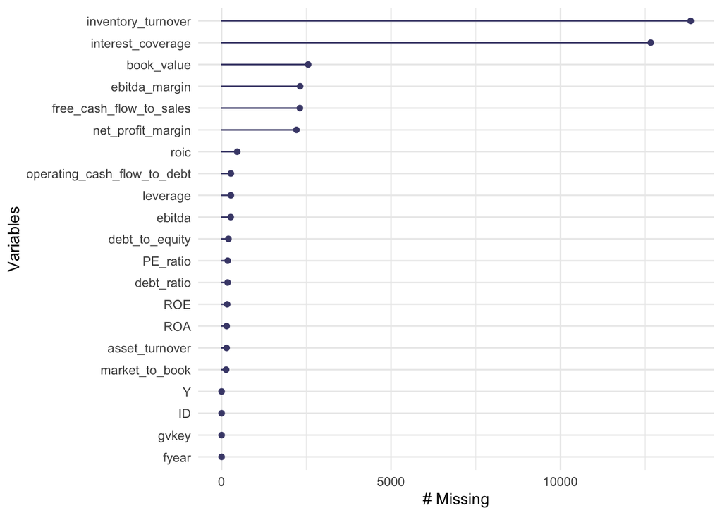

```r
gg_miss_var(data)  # Plot missing values by variable
```

#### 1. High missingness

```r
data <- data %>%
  select(-inventory_turnover, -interest_coverage)
```

#### Distribution of missing values

We want to know in which case we are based on these kind of distributions:

**a. Univariate Missing Values:** If the same individuals have missing values for the same (d < p) variables.

**b. Monotonic Missing Values:** If the variables can be ordered so that, when the observation (y_{ij}) is missing for the variable (Y_j), then all the following variables for the same individual, (y_{ik}, k > j), are also missing.

**c. Non-Monotonic or Arbitrary Missing Values:** If the missing values are without structure, i.e., they are distributed without particular structure in the dataset.

```r
# Créer un dataset avec les lignes ayant au moins une valeur manquante
rows_with_na <- data %>%
  filter(if_any(everything(), is.na))

# Afficher le nouveau dataset
print(rows_with_na)
```

```
# A tibble: 5,021 × 19
   gvkey  fyear     Y ID             ROA    ROE net_profit_margin asset_turnover
   <chr>  <int> <dbl> <chr>        <dbl>  <dbl>             <dbl>          <dbl>
 1 001234  2020     0 001234_20… 0.120   0.134             0.218           0.553
 2 001234  2021     0 001234_20… 0.124   0.135             0.200           0.617
 3 001234  2022     0 001234_20… 0.132   0.146             0.191           0.693
 4 001234  2023     0 001234_20… 0.0744  0.0799            0.115           0.649
 5 001239  2010     0 001239_20… 0.0827  0.117             0.0972          0.851
 6 001274  2017     0 001274_20… 0.00355 0.0106            0.0140          0.253
 7 001327  2010     0 001327_20… 0.0878  0.104             0.128           0.685
 8 001327  2011     0 001327_20… 0.120   0.141             0.160           0.751
 9 001327  2012     0 001327_20… 0.0946  0.106             0.129           0.734
10 001327  2013     0 001327_20… 0.119   0.132             0.155           0.768
# ℹ 5,011 more rows
# ℹ 11 more variables: debt_to_equity <dbl>, debt_ratio <dbl>, PE_ratio <dbl>,
#   market_to_book <dbl>, operating_cash_flow_to_debt <dbl>,
#   free_cash_flow_to_sales <dbl>, book_value <dbl>, ebitda <dbl>,
#   ebitda_margin <dbl>, roic <dbl>, leverage <dbl>
```

```r
# Compter le nombre distinct de colonnes avec des valeurs manquantes par gvkey
missing_values_per_gvkey <- data %>%
  group_by(gvkey) %>%
  summarise(
    distinct_missing_columns = sum(sapply(across(everything(), is.na), any))
  )
```

```r
missing_distribution <- missing_values_per_gvkey %>%
  group_by(distinct_missing_columns) %>% # Grouper par nombre de colonnes avec NA
  summarise(
    count_gvkey = n() # Compter le nombre de gvkey pour chaque groupe
  ) %>%
  arrange(distinct_missing_columns) # Trier par nombre de colonnes avec NA

# Afficher les résultats
print(missing_distribution)
```

```
# A tibble: 13 × 2
   distinct_missing_columns count_gvkey
                      <int>       <int>
 1                        0        4380
 2                        1         676
 3                        2          63
 4                        3         696
 5                        4          30
 6                        5          41
 7                        6          16
 8                        8           5
 9                        9           4
10                       10          52
11                       11           3
12                       13           1
13                       15          73
```

```r
# Supprimer les gvkey avec au moins 5 distinct_missing_columns
data <- data %>%
  left_join(missing_values_per_gvkey, by = "gvkey") %>% # Joindre avec les informations des colonnes manquantes
  filter(distinct_missing_columns < 5 | is.na(distinct_missing_columns)) %>% # Garder les gvkey avec moins de 5 colonnes manquantes
  select(-distinct_missing_columns) # Optionnel : Supprimer la colonne supplémentaire si elle n'est plus nécessaire

# Afficher le dataset filtré
print(data)
```

```
# A tibble: 43,919 × 19
   gvkey  fyear     Y ID            ROA     ROE net_profit_margin asset_turnover
   <chr>  <int> <dbl> <chr>       <dbl>   <dbl>             <dbl>          <dbl>
 1 001004  2010     0 001004_2… 0.0410  0.0835            0.0393           1.04
 2 001004  2011     0 001004_2… 0.0308  0.0783            0.0326           0.945
 3 001004  2012     0 001004_2… 0.0257  0.0599            0.0254           1.01
 4 001004  2013     0 001004_2… 0.0331  0.0729            0.0358           0.925
 5 001004  2014     0 001004_2… 0.00673 0.0121            0.00640          1.05
 6 001004  2015     0 001004_2… 0.0331  0.0551            0.0287           1.15
 7 001004  2016     0 001004_2… 0.0376  0.0618            0.0320           1.18
 8 001004  2017     0 001004_2… 0.0102  0.0167            0.00892          1.15
 9 001004  2018     0 001004_2… 0.00494 0.00828           0.00366          1.35
10 001004  2019     0 001004_2… 0.00212 0.00487           0.00211          1.00
# ℹ 43,909 more rows
# ℹ 11 more variables: debt_to_equity <dbl>, debt_ratio <dbl>, PE_ratio <dbl>,
#   market_to_book <dbl>, operating_cash_flow_to_debt <dbl>,
#   free_cash_flow_to_sales <dbl>, book_value <dbl>, ebitda <dbl>,
#   ebitda_margin <dbl>, roic <dbl>, leverage <dbl>
```

We will look at the remaining missing values

```r
# Check for missing values and give the proportion of missing values by column
missing_values <- data %>%
  summarise(across(everything(), ~ sum(is.na(.)) / n())) %>%
  gather() %>%
  arrange(desc(value))

# Print missing values
print(missing_values)
```

```
# A tibble: 19 × 2
   key                            value
   <chr>                          <dbl>
 1 book_value                  0.0544
 2 ebitda_margin               0.0464
 3 free_cash_flow_to_sales     0.0461
 4 net_profit_margin           0.0441
 5 roic                        0.00392
 6 ebitda                      0.00232
 7 leverage                    0.00159
 8 market_to_book              0.000774
 9 PE_ratio                    0.000638
10 operating_cash_flow_to_debt 0.000478
11 ROE                         0.000250
12 debt_to_equity              0.000250
13 gvkey                       0
14 fyear                       0
15 Y                           0
16 ID                          0
17 ROA                         0
18 asset_turnover              0
19 debt_ratio                  0
```

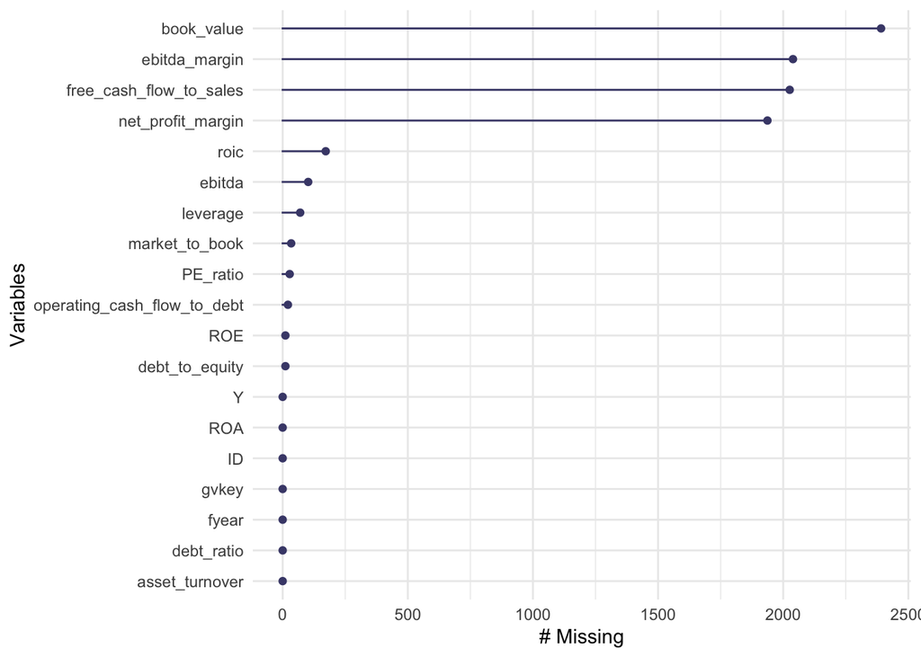

```r
gg_miss_var(data)  # Plot missing values by variable
```

#### 2. Moderate Missingness

```r
summary(data$book_value)
```

```
    Min.  1st Qu.   Median     Mean  3rd Qu.     Max.     NA's
  -13.32    53.61   456.88  3949.04  2228.48 93472.65     2391
```

Feature correlation analysis to asses the relevance of imputation

```r
numeric_data <- data %>% select(where(is.numeric))

correlations <- numeric_data %>%
  summarise(across(everything(), ~ cor(.x, numeric_data$book_value, use = "complete.obs")))

correlation_df <- tibble(variable = colnames(numeric_data), correlation = as.numeric(correlations))
```

Heatmap

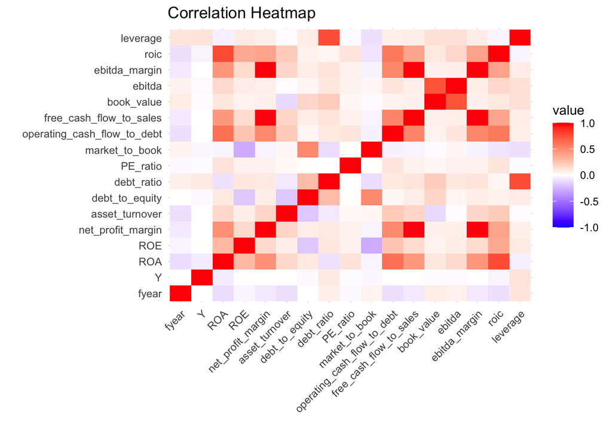

```r
correlation_matrix <- cor(numeric_data, use = "complete.obs")

# Transformer la matrice en un format long pour ggplot
melted_correlation <- melt(correlation_matrix)

# Heatmap des corrélations
ggplot(melted_correlation, aes(x = Var1, y = Var2, fill = value)) +
  geom_tile() +
  scale_fill_gradient2(low = "blue", high = "red", mid = "white", midpoint = 0, limit = c(-1, 1)) +
  theme_minimal() +
  labs(title = "Correlation Heatmap", x = "", y = "") +
  theme(axis.text.x = element_text(angle = 45, hjust = 1))
```

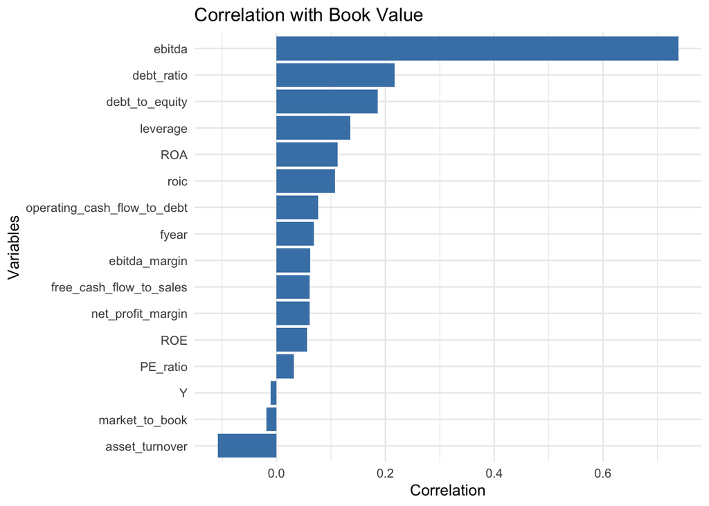

```r
correlation_with_book_value <- correlation_df %>%
  filter(variable != "book_value") # Exclure la corrélation avec elle-même

ggplot(correlation_with_book_value, aes(x = reorder(variable, correlation), y = correlation)) +
  geom_bar(stat = "identity", fill = "steelblue") +
  coord_flip() +
  theme_minimal() +
  labs(title = "Correlation with Book Value", x = "Variables", y = "Correlation")
```

We can see that ebitda and book value are higly correlated, we can think of use ebitda to impute missing values in book_value

```r
# Filtrer les lignes où book_value est NA
rows_with_na_book_value <- data %>%
  filter(is.na(book_value))

# Afficher le dataset résultant
print(rows_with_na_book_value)
```

```
# A tibble: 2,391 × 19
   gvkey  fyear     Y ID              ROA   ROE net_profit_margin asset_turnover
   <chr>  <int> <dbl> <chr>         <dbl> <dbl>             <dbl>          <dbl>
 1 001239  2010     0 001239_2010 0.0827  0.117           0.0972           0.851
 2 001327  2010     0 001327_2010 0.0878  0.104           0.128            0.685
 3 001327  2011     0 001327_2011 0.120   0.141           0.160            0.751
 4 001327  2012     0 001327_2012 0.0946  0.106           0.129            0.734
 5 001327  2013     0 001327_2013 0.119   0.132           0.155            0.768
 6 001327  2014     0 001327_2014 0.154   0.181           0.200            0.771
 7 001327  2015     0 001327_2015 0.215   0.253           0.245            0.876
 8 001327  2016     0 001327_2016 0.258   0.281           0.303            0.853
 9 001382  2010     0 001382_2010 0.0642  5.01            0.0422           1.52
10 001382  2011     0 001382_2011 0.00852 0.473           0.00544          1.57
# ℹ 2,381 more rows
# ℹ 11 more variables: debt_to_equity <dbl>, debt_ratio <dbl>, PE_ratio <dbl>,
#   market_to_book <dbl>, operating_cash_flow_to_debt <dbl>,
#   free_cash_flow_to_sales <dbl>, book_value <dbl>, ebitda <dbl>,
#   ebitda_margin <dbl>, roic <dbl>, leverage <dbl>
```

```r
summary(data$free_cash_flow_to_sales)
```

```
    Min.  1st Qu.   Median     Mean  3rd Qu.     Max.     NA's
-70.8481  -0.0439   0.0484  -1.3788   0.1446   0.6484     2026
```

```r
summary(data$ebitda_margin)
```

```
    Min.  1st Qu.   Median     Mean  3rd Qu.     Max.     NA's
-82.5545   0.0281   0.1286  -1.5030   0.2732   0.6737     2039
```

```r
summary(data$net_profit_margin)
```

```
    Min.  1st Qu.   Median     Mean  3rd Qu.     Max.     NA's
-88.4300  -0.0645   0.0403  -1.7761   0.1177   0.5200     1937
```

#### Imputation

**MICE with Predictive Mean Matching (PMM)** is a robust method for handling missing data. MICE iteratively imputes missing values by modeling each variable conditionally on others.

**PMM** predicts missing values using regression and replaces them with observed values closest to the prediction, ensuring realistic imputations that respect the original data distribution.

With `m = 5`, multiple datasets are generated to account for imputation uncertainty, and `seed = 123` ensures reproducibility. This approach reduces bias, preserves variability, and produces reliable analyses by addressing missing data effectively.

[output not shown]

## Descriptive Statistics

#### Target Variable

```r
# Calculer les gvkey ayant au moins une fois Y = 1
gvkey_with_Y1 <- data %>%
  group_by(gvkey) %>% # Grouper par gvkey
  summarise(has_Y1 = any(Y == 1)) %>% # Vérifier si Y = 1 existe pour chaque gvkey
  summarise(proportion_Y1 = mean(has_Y1)) # Calculer la proportion

# Afficher la proportion
print(gvkey_with_Y1)
```

```
# A tibble: 1 × 1
  proportion_Y1
          <dbl>
1        0.0274
```

We have almost 3% of company that have bankrupted

## Survival analysis (Hazard Model)

**Survival Analysis in Bankruptcy Scoring**

Survival analysis is a statistical approach to predict the time to an event, such as a company’s bankruptcy. The **Cox Proportional Hazards Model** is used to evaluate the relationship between financial ratios and the hazard of bankruptcy. This model estimates how variables like profitability (e.g., ROA, ROE), leverage (e.g., debt-to-equity, debt ratio), and efficiency (e.g., asset turnover) impact the likelihood of bankruptcy over time.

In the code, the model is fitted with financial variables as predictors and time-to-bankruptcy as the survival outcome. The results reveal the significant factors influencing the bankruptcy risk.

Create time and status variables

```r
# Prepare survival data
df <- data %>%
  group_by(gvkey) %>% # Group by firm identifier
  mutate(time = fyear - min(fyear),  # Calculate time-to-event
         status = Y) %>%            # Status (1 = bankruptcy, 0 = no event)
  ungroup()
```

Fit the Cox Proportional Hazards Model (all the variables except ones define below with values goes to infinity)

```r
# Fit the Cox Proportional Hazards Model
cox_model <- coxph(Surv(time, status) ~
                     ROA + ROE + net_profit_margin + asset_turnover +
                     debt_to_equity + debt_ratio + PE_ratio +
                     market_to_book + operating_cash_flow_to_debt +
                     free_cash_flow_to_sales + ebitda_margin + roic + leverage,
                   data = df)

# View model summary
summary(cox_model)
```

```
Call:
coxph(formula = Surv(time, status) ~ ROA + ROE + net_profit_margin +
    asset_turnover + debt_to_equity + debt_ratio + PE_ratio +
    market_to_book + operating_cash_flow_to_debt + free_cash_flow_to_sales +
    ebitda_margin + roic + leverage, data = df)

  n= 43919, number of events= 165

                                 coef exp(coef)  se(coef)      z Pr(>|z|)
ROA                         -1.530601  0.216406  0.217222 -7.046 1.84e-12 ***
ROE                         -0.115096  0.891280  0.046795 -2.460  0.01391 *
net_profit_margin            0.082700  1.086216  0.025601  3.230  0.00124 **
asset_turnover              -0.207946  0.812251  0.130914 -1.588  0.11219
debt_to_equity              -0.014424  0.985679  0.015279 -0.944  0.34515
debt_ratio                  -0.074866  0.927868  0.490412 -0.153  0.87867
PE_ratio                    -0.003923  0.996085  0.001418 -2.766  0.00567 **
market_to_book              -0.003850  0.996157  0.011519 -0.334  0.73820
operating_cash_flow_to_debt  0.143721  1.154562  0.149823  0.959  0.33742
free_cash_flow_to_sales     -0.020977  0.979241  0.038674 -0.542  0.58753
ebitda_margin               -0.063544  0.938433  0.031885 -1.993  0.04627 *
roic                         0.429924  1.537140  0.151399  2.840  0.00452 **
leverage                     1.965214  7.136440  0.326827  6.013 1.82e-09 ***
---
Signif. codes:  0 '***' 0.001 '**' 0.01 '*' 0.05 '.' 0.1 ' ' 1

                            exp(coef) exp(-coef) lower .95 upper .95
ROA                            0.2164     4.6210    0.1414    0.3313
ROE                            0.8913     1.1220    0.8132    0.9769
net_profit_margin              1.0862     0.9206    1.0331    1.1421
asset_turnover                 0.8123     1.2311    0.6284    1.0498
debt_to_equity                 0.9857     1.0145    0.9566    1.0156
debt_ratio                     0.9279     1.0777    0.3549    2.4262
PE_ratio                       0.9961     1.0039    0.9933    0.9989
market_to_book                 0.9962     1.0039    0.9739    1.0189
operating_cash_flow_to_debt    1.1546     0.8661    0.8608    1.5486
free_cash_flow_to_sales        0.9792     1.0212    0.9078    1.0564
ebitda_margin                  0.9384     1.0656    0.8816    0.9990
roic                           1.5371     0.6506    1.1425    2.0682
leverage                       7.1364     0.1401    3.7609   13.5418

Concordance= 0.824  (se = 0.025 )
Likelihood ratio test= 298.4  on 13 df,   p=<2e-16
Wald test            = 459.9  on 13 df,   p=<2e-16
Score (logrank) test = 681  on 13 df,   p=<2e-16
```

### Model evaluation

The C-index measures the model’s ability to rank survival times correctly.

```r
# Concordance index
cox_summary <- summary(cox_model)
c_index <- cox_summary$concordance[1]  # First element of concordance contains the C-index
cat("Concordance Index (C-Index):", c_index, "\n")
```

```
Concordance Index (C-Index): 0.8236046
```

risk scores (linear predictors) to use them for stratification or classification

```r
# Compute risk scores
risk_scores <- predict(cox_model, type = "risk")

# Add risk scores to the dataset
df <- df %>%
  mutate(risk_score = risk_scores)
```

If we dichotomize the risk (e.g., high vs. low risk based on the median risk score), you can compute confusion matrices.

```r
# Dichotomize risk scores: high risk (1) vs. low risk (0) based on the median
threshold <- median(risk_scores)
df <- df %>%
  mutate(predicted_status = ifelse(risk_score > threshold, 1, 0))

# Create confusion matrix
library(caret)
confusion <- confusionMatrix(as.factor(df$predicted_status), as.factor(df$status))
print(confusion)
```

```
Confusion Matrix and Statistics

          Reference
Prediction     0     1
         0 21943    17
         1 21811   148

               Accuracy : 0.503
                 95% CI : (0.4983, 0.5077)
    No Information Rate : 0.9962
    P-Value [Acc > NIR] : 1

                  Kappa : 0.006

 Mcnemar's Test P-Value : <2e-16

            Sensitivity : 0.50151
            Specificity : 0.89697
         Pos Pred Value : 0.99923
         Neg Pred Value : 0.00674
             Prevalence : 0.99624
         Detection Rate : 0.49962
   Detection Prevalence : 0.50001
      Balanced Accuracy : 0.69924

       'Positive' Class : 0
```

## Logistic Model

```r
df <- data %>%
  group_by(gvkey) %>% # Group by firm identifier
  mutate(time = fyear - min(fyear),  # Calculate time-to-event
         status = Y) %>%            # Status (1 = bankruptcy, 0 = no event)
  ungroup()
```

```r
str(df)
```

```
tibble [43,919 × 21] (S3: tbl_df/tbl/data.frame)
 $ gvkey                      : chr [1:43919] "001004" "001004" "001004" "001004" ...
 $ fyear                      : int [1:43919] 2010 2011 2012 2013 2014 2015 2016 2017 2018 2019 ...
 $ Y                          : num [1:43919] 0 0 0 0 0 0 0 0 0 0 ...
 $ ID                         : chr [1:43919] "001004_2010" "001004_2011" "001004_2012" "001004_2013" ...
 $ ROA                        : num [1:43919] 0.04098 0.03084 0.02574 0.03314 0.00673 ...
 $ ROE                        : num [1:43919] 0.0835 0.0783 0.0599 0.0729 0.0121 ...
 $ net_profit_margin          : num [1:43919] 0.0393 0.0326 0.0254 0.0358 0.0064 ...
 $ asset_turnover             : num [1:43919] 1.042 0.945 1.014 0.925 1.052 ...
 $ debt_to_equity             : num [1:43919] 1.039 1.538 1.325 1.199 0.793 ...
 $ debt_ratio                 : num [1:43919] 0.51 0.606 0.57 0.545 0.442 ...
 $ PE_ratio                   : num [1:43919] 12.3 14.3 11.8 12.6 92.7 ...
 $ market_to_book             : num [1:43919] 1.03 1.118 0.704 0.92 1.119 ...
 $ operating_cash_flow_to_debt: num [1:43919] 0.125 0.0709 0.1338 0.1166 -0.0642 ...
 $ free_cash_flow_to_sales    : num [1:43919] -0.00917 0.00145 0.05782 0.05568 -0.05601 ...
 $ book_value                 : num [1:43919] 770 1215 1080 1038 565 ...
 $ ebitda                     : num [1:43919] 196.3 222.7 245.2 256 83.7 ...
 $ ebitda_margin              : num [1:43919] 0.1105 0.1073 0.1131 0.1258 0.0525 ...
 $ roic                       : num [1:43919] 0.1534 0.1344 0.1507 0.1567 0.0838 ...
 $ leverage                   : num [1:43919] 0.347 0.478 0.435 0.388 0.154 ...
 $ time                       : int [1:43919] 0 1 2 3 4 5 6 7 8 9 ...
 $ status                     : num [1:43919] 0 0 0 0 0 0 0 0 0 0 ...
```

```r
# Create a formula for the logistic regression
# Exclude non-numeric predictors like gvkey, ID, and time
predictors <- names(df)[!names(df) %in% c("gvkey", "fyear", "ID", "Y", "status")]

# Construct the formula dynamically
formula <- as.formula(paste("Y ~", paste(predictors, collapse = " + ")))

# Fit the logistic regression model
logistic_model <- glm(formula, data = df, family = binomial)

# Summarize the model
summary(logistic_model)
```

```
Call:
glm(formula = formula, family = binomial, data = df)

Coefficients:
                              Estimate Std. Error z value Pr(>|z|)
(Intercept)                 -6.511e+00  2.502e-01 -26.027  < 2e-16 ***
ROA                         -1.499e+00  2.540e-01  -5.903 3.57e-09 ***
ROE                         -1.369e-01  5.002e-02  -2.738  0.00619 **
net_profit_margin            7.441e-02  2.343e-02   3.176  0.00149 **
asset_turnover              -2.260e-01  1.264e-01  -1.789  0.07363 .
debt_to_equity              -1.510e-02  1.437e-02  -1.051  0.29325
debt_ratio                  -1.018e-01  4.365e-01  -0.233  0.81561
PE_ratio                    -2.098e-03  1.432e-03  -1.465  0.14285
market_to_book              -7.010e-03  1.122e-02  -0.624  0.53230
operating_cash_flow_to_debt  2.871e-01  1.588e-01   1.808  0.07055 .
free_cash_flow_to_sales     -1.496e-02  3.550e-02  -0.422  0.67337
book_value                   1.749e-05  1.402e-05   1.248  0.21202
ebitda                      -1.585e-03  3.659e-04  -4.332 1.48e-05 ***
ebitda_margin               -5.592e-02  2.883e-02  -1.940  0.05244 .
roic                         7.483e-01  1.678e-01   4.459 8.24e-06 ***
leverage                     2.231e+00  2.837e-01   7.864 3.72e-15 ***
time                         3.147e-03  2.159e-02   0.146  0.88411
---
Signif. codes:  0 '***' 0.001 '**' 0.01 '*' 0.05 '.' 0.1 ' ' 1

(Dispersion parameter for binomial family taken to be 1)

    Null deviance: 2172.2  on 43918  degrees of freedom
Residual deviance: 1815.7  on 43902  degrees of freedom
AIC: 1849.7

Number of Fisher Scoring iterations: 11
```

The logistic regression model evaluates the relationship between financial variables and the probability of bankruptcy. Key results:

- **Significant Predictors**:
  - **ROA**: Negative coefficient (-1.499, *p* < 0.001) indicates higher ROA reduces bankruptcy risk.
  - **ROE**: Negative coefficient (-0.137, *p* < 0.01) suggests higher ROE lowers risk.
  - **Net Profit Margin**: Positive coefficient (0.074, *p* < 0.01) suggests higher margins increase bankruptcy likelihood, potentially due to overstated profits.
  - **EBITDA**: Negative coefficient (-0.0016, *p* < 0.001) implies higher EBITDA reduces risk.
  - **ROIC**: Positive coefficient (0.748, *p* < 0.001) indicates higher ROIC increases risk, possibly signaling aggressive reinvestment strategies.
  - **Leverage**: Strong positive effect (2.231, *p* < 0.001) highlights higher leverage as a key bankruptcy driver.
- **Non-Significant Predictors**: Variables like debt-to-equity, debt ratio, and market-to-book ratio showed no significant effect (*p* > 0.1).
- **Model Fit**:
  - Residual deviance decreased substantially (2172.2 to 1815.7), and the AIC is 1849.7, indicating a good fit.

This model identifies leverage and profitability measures as critical indicators of bankruptcy risk, providing actionable insights for financial analysis.

```r
data <- df
```

### Prediction Evaluation

**Train-Test split**

```r
# Step 2: Train-test split
set.seed(123)  # Set seed for reproducibility
train_index <- createDataPartition(data$Y, p = 0.7, list = FALSE)  # 70% training data
train_data <- data[train_index, ]
test_data <- data[-train_index, ]
```

**Train the model**

```r
# Step 3: Train the Logistic Regression Model
# Exclude non-numeric predictors like gvkey, ID, and time
predictors <- names(data)[!names(data) %in% c("gvkey", "fyear", "ID", "Y", "status")]

# Construct the formula dynamically
formula <- as.formula(paste("Y ~", paste(predictors, collapse = " + ")))

# Fit the logistic regression model
logistic_model <- glm(formula, data = data, family = binomial)
```

**Summarize the Model**

```r
# Step 4: Summarize the Model
summary(logistic_model)
```

```
Call:
glm(formula = formula, family = binomial, data = data)

Coefficients:
                              Estimate Std. Error z value Pr(>|z|)
(Intercept)                 -6.511e+00  2.502e-01 -26.027  < 2e-16 ***
ROA                         -1.499e+00  2.540e-01  -5.903 3.57e-09 ***
ROE                         -1.369e-01  5.002e-02  -2.738  0.00619 **
net_profit_margin            7.441e-02  2.343e-02   3.176  0.00149 **
asset_turnover              -2.260e-01  1.264e-01  -1.789  0.07363 .
debt_to_equity              -1.510e-02  1.437e-02  -1.051  0.29325
debt_ratio                  -1.018e-01  4.365e-01  -0.233  0.81561
PE_ratio                    -2.098e-03  1.432e-03  -1.465  0.14285
market_to_book              -7.010e-03  1.122e-02  -0.624  0.53230
operating_cash_flow_to_debt  2.871e-01  1.588e-01   1.808  0.07055 .
free_cash_flow_to_sales     -1.496e-02  3.550e-02  -0.422  0.67337
book_value                   1.749e-05  1.402e-05   1.248  0.21202
ebitda                      -1.585e-03  3.659e-04  -4.332 1.48e-05 ***
ebitda_margin               -5.592e-02  2.883e-02  -1.940  0.05244 .
roic                         7.483e-01  1.678e-01   4.459 8.24e-06 ***
leverage                     2.231e+00  2.837e-01   7.864 3.72e-15 ***
time                         3.147e-03  2.159e-02   0.146  0.88411
---
Signif. codes:  0 '***' 0.001 '**' 0.01 '*' 0.05 '.' 0.1 ' ' 1

(Dispersion parameter for binomial family taken to be 1)

    Null deviance: 2172.2  on 43918  degrees of freedom
Residual deviance: 1815.7  on 43902  degrees of freedom
AIC: 1849.7

Number of Fisher Scoring iterations: 11
```

**Evaluate the model on test data**

```r
# Step 5: Evaluate the Model on Test Data
# Predict probabilities for the test set
test_data <- test_data %>%
  mutate(predicted_prob = predict(logistic_model, newdata = ., type = "response"))

# Create predictions based on a cutoff (e.g., 0.5)
test_data <- test_data %>%
  mutate(predicted_class = ifelse(predicted_prob > 0.3, 1, 0))
```

**Model Evaluation Metrics**

```r
# Confusion Matrix
confusion_matrix <- table(Predicted = test_data$predicted_class, Actual = test_data$Y)
print("Confusion Matrix:")
```

```
[1] "Confusion Matrix:"
```

```r
print(confusion_matrix)
```

```
         Actual
Predicted     0     1
        0 13126    46
        1     2     1
```

```r
# Accuracy
accuracy <- sum(diag(confusion_matrix)) / sum(confusion_matrix)
print(paste("Accuracy:", round(accuracy, 4)))
```

```
[1] "Accuracy: 0.9964"
```

```r
# Precision (for the positive class)
precision <- confusion_matrix[2, 2] / sum(confusion_matrix[2, ])
print(paste("Precision:", round(precision, 4)))
```

```
[1] "Precision: 0.3333"
```

```r
# Recall (Sensitivity or True Positive Rate)
recall <- confusion_matrix[2, 2] / sum(confusion_matrix[, 2])
print(paste("Recall (Sensitivity):", round(recall, 4)))
```

```
[1] "Recall (Sensitivity): 0.0213"
```

```r
# Specificity (True Negative Rate)
specificity <- confusion_matrix[1, 1] / sum(confusion_matrix[, 1])
print(paste("Specificity:", round(specificity, 4)))
```

```
[1] "Specificity: 0.9998"
```

```r
# F1 Score
f1_score <- 2 * ((precision * recall) / (precision + recall))
print(paste("F1 Score:", round(f1_score, 4)))
```

```
[1] "F1 Score: 0.04"
```

```r
# ROC Curve and AUC
roc_curve <- roc(test_data$Y, test_data$predicted_prob)
print(paste("AUC:", round(auc(roc_curve), 4)))
```

```
[1] "AUC: 0.7859"
```

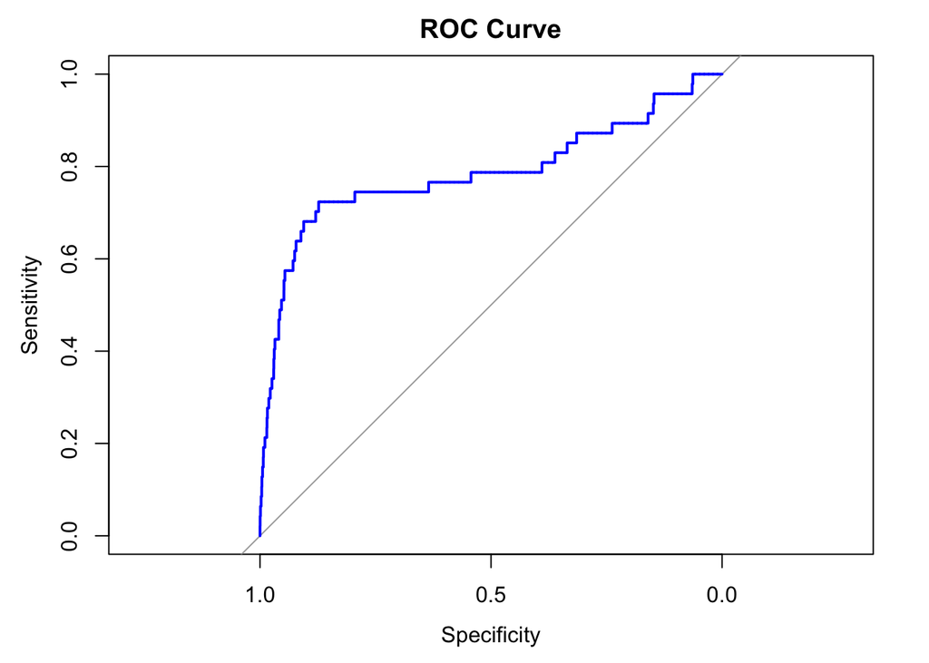

```r
plot(roc_curve, col = "blue", main = "ROC Curve")
```

```r
auc(roc_curve)
```

```
Area under the curve: 0.7859
```

**Cross Validation to choose the threshold**

This code performs an analysis to determine the optimal classification threshold for a binary classification model, using cross-validation to evaluate performance across multiple metrics. Here’s a breakdown of the process:

1. **Define Thresholds**:
   - A sequence of thresholds (0 to 1 in steps of 0.01) is defined to evaluate model predictions.
2. **Metrics Calculation**:
   - For each threshold, predicted probabilities (`predicted_prob`) are converted into binary predictions (`predicted_class`) based on whether they exceed the threshold.
   - A confusion matrix is generated for the predictions to calculate key metrics:
     - **Accuracy**: Overall correctness.
     - **Precision**: Correct positive predictions among all positive predictions.
     - **Recall**: Correct positive predictions among all actual positives.
     - **F1 Score**: Harmonic mean of precision and recall.
3. **Cross-Validation Results**:
   - The calculated metrics are stored in a dataframe (`cv_results`) for all thresholds.
4. **Optimal Threshold**:
   - The threshold maximizing a chosen metric (e.g., F1 Score) is identified and printed as the optimal threshold.
5. **Visualization**:
   - Metrics are plotted against thresholds using a line plot, showing how each metric varies with the threshold.

This approach ensures the model’s classification threshold is tuned to balance the trade-offs between precision, recall, and other performance measures, aligning with the specific objectives of the analysis.

```r
# Define a sequence of thresholds to test
thresholds <- seq(0, 1, by = 0.01)

# Initialize a dataframe to store results
cv_results <- data.frame(threshold = thresholds, accuracy = NA, precision = NA, recall = NA, f1_score = NA)

# Perform cross-validation for each threshold
for (i in seq_along(thresholds)) {
  threshold <- thresholds[i]

  # Create predictions based on the current threshold
  test_data <- test_data %>%
    mutate(predicted_class = ifelse(predicted_prob > threshold, 1, 0))

  # Confusion Matrix
  confusion_matrix <- table(Predicted = test_data$predicted_class, Actual = test_data$Y)

  # Handle cases where the confusion matrix dimensions are insufficient
  tp <- ifelse("1" %in% rownames(confusion_matrix) & "1" %in% colnames(confusion_matrix), confusion_matrix["1", "1"], 0)
  fp <- ifelse("1" %in% rownames(confusion_matrix) & "0" %in% colnames(confusion_matrix), confusion_matrix["1", "0"], 0)
  fn <- ifelse("0" %in% rownames(confusion_matrix) & "1" %in% colnames(confusion_matrix), confusion_matrix["0", "1"], 0)
  tn <- ifelse("0" %in% rownames(confusion_matrix) & "0" %in% colnames(confusion_matrix), confusion_matrix["0", "0"], 0)

  # Calculate metrics
  accuracy <- (tp + tn) / sum(confusion_matrix)
  precision <- ifelse(tp + fp > 0, tp / (tp + fp), NA)
  recall <- ifelse(tp + fn > 0, tp / (tp + fn), NA)
  f1_score <- ifelse(!is.na(precision) & !is.na(recall) & (precision + recall > 0), 2 * ((precision * recall) / (precision + recall)), NA)

  # Store metrics in cv_results
  cv_results[i, ] <- c(threshold, accuracy, precision, recall, f1_score)
}

# Find the optimal threshold based on a specific metric (e.g.,recall)
optimal_threshold <- cv_results %>% filter(f1_score == max(f1_score, na.rm = TRUE))
print(optimal_threshold)
```

```
  threshold  accuracy  precision    recall  f1_score
1      0.06 0.9896774 0.07619048 0.1702128 0.1052632
```

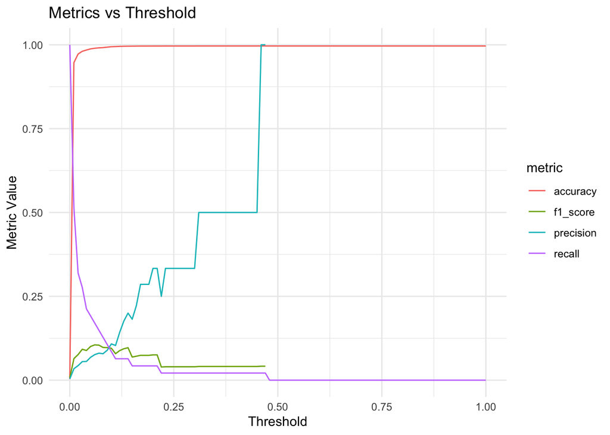

```r
# Plot metrics against thresholds
cv_results_long <- cv_results %>%
  pivot_longer(cols = c(accuracy, precision, recall, f1_score), names_to = "metric", values_to = "value")

ggplot(cv_results_long, aes(x = threshold, y = value, color = metric)) +
  geom_line() +
  labs(title = "Metrics vs Threshold", x = "Threshold", y = "Metric Value") +
  theme_minimal()
```

```r
# Extract the optimal threshold
optimal_threshold_value <- optimal_threshold$threshold[1]

# Create predictions based on the optimal threshold
test_data <- test_data %>%
  mutate(predicted_class = ifelse(predicted_prob > optimal_threshold_value, 1, 0))

# Generate the confusion matrix
confusion_matrix_optimal <- table(Predicted = test_data$predicted_class, Actual = test_data$Y)

# Print the confusion matrix
print("Confusion Matrix at Optimal Threshold:")
```

```
[1] "Confusion Matrix at Optimal Threshold:"
```

```r
print(confusion_matrix_optimal)
```

```
         Actual
Predicted     0     1
        0 13031    39
        1    97     8
```

## Time Series Cross-Validation

**Steps:**

```r
# Step 1: Prepare data
# Step 2: Sort data by firm (gvkey) and year (fyear) to respect temporal structure
data <- data %>% arrange(gvkey, fyear)

# Step 3: Define Time Series Cross-Validation (Walk Forward Scheme)
# Create custom indices for training and testing
time_series_cv <- function(data, n_splits) {
  indices <- list()
  n <- nrow(data)
  split_size <- floor(n / (n_splits + 1))  # Calculate split size

  for (i in 1:n_splits) {
    train_end <- split_size * i  # End index for training
    test_start <- train_end + 1
    test_end <- test_start + split_size - 1

    if (test_end > n) break  # Ensure test indices stay within range

    train_indices <- seq(1, train_end)
    test_indices <- seq(test_start, test_end)

    indices[[i]] <- list(train = train_indices, test = test_indices)
  }
  indices
}
```

```r
# Create 5 splits for time series CV
n_splits <- 5
cv_indices <- time_series_cv(data, n_splits)
```

```r
# Step 4: Perform Walk Forward Validation
results <- list()

for (i in seq_along(cv_indices)) {
  # Get train and test data
  train_data <- data[cv_indices[[i]]$train, ]
  test_data <- data[cv_indices[[i]]$test, ]

  # Fit logistic regression model on training data
  logistic_model <- glm(
    Y ~ ROA + ROE + net_profit_margin + asset_turnover +
       debt_to_equity + debt_ratio + PE_ratio +
       market_to_book + operating_cash_flow_to_debt +
       free_cash_flow_to_sales + ebitda_margin + roic + leverage,
    family = binomial(link = "logit"),
    data = train_data
  )

  # Predict probabilities on test data
  test_data <- test_data %>%
    mutate(predicted_prob = predict(logistic_model, newdata = ., type = "response"),
           predicted_class = ifelse(predicted_prob > 0.5, 1, 0))

  # Evaluate model performance
  confusion_matrix <- table(test_data$predicted_class, test_data$Y)
  accuracy <- sum(diag(confusion_matrix)) / sum(confusion_matrix)
  roc_curve <- roc(test_data$Y, test_data$predicted_prob)
  auc <- auc(roc_curve)

  # Store results
  results[[i]] <- list(
    fold = i,
    accuracy = accuracy,
    auc = auc,
    confusion_matrix = confusion_matrix,
    roc_curve = roc_curve
  )
}
```

```r
# Step 5: Summarize Results
accuracy_list <- sapply(results, function(x) x$accuracy)
auc_list <- sapply(results, function(x) x$auc)

cat("Walk Forward Validation Results:\n")
```

```
Walk Forward Validation Results:
```

```r
cat("Average Accuracy:", round(mean(accuracy_list), 4), "\n")
```

```
Average Accuracy: 0.9957
```

```r
cat("Average AUC:", round(mean(auc_list), 4), "\n")
```

```
Average AUC: 0.7879
```

**Walk Forward Validation Results Interpretation**

The model achieved an **average accuracy of 99.57%**, indicating that it correctly classified nearly all observations in the test sets. However, the **average AUC of 0.7879** suggests moderate discriminatory power, meaning the model performs reasonably well in distinguishing between the two classes but leaves room for improvement.

This discrepancy between accuracy and AUC highlights that while the model predicts the majority class well, it might struggle with imbalanced data or correctly classifying the minority class.

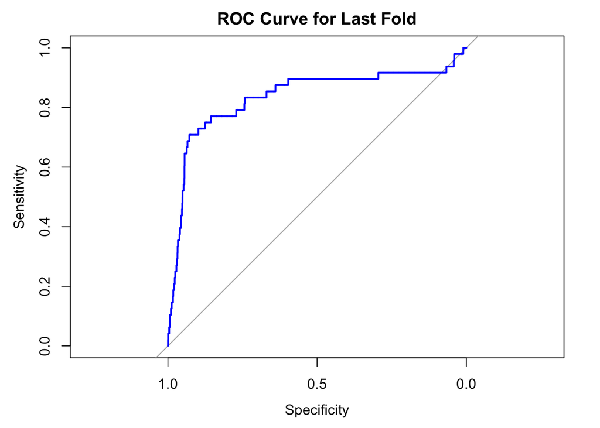

```r
# Plot the last ROC curve as an example
plot(results[[n_splits]]$roc_curve, col = "blue", main = "ROC Curve for Last Fold")
```